# Reimbursement Exploratory Data Analysis

### Business Purposes in End of 2018

From the word cloud, we know that we have a large portion of expense entries in the end of 2018 spent for **China GM Summit**.

```python
df.info()
```

```
<class 'pandas.core.frame.DataFrame'>
Int64Index: 6357 entries, 0 to 6356
Data columns (total 10 columns):
Sub                      6357 non-null object
Payment Type             6357 non-null object
Parent Expense Type      6357 non-null object
Expense Type             6357 non-null object
Sent for Payment Date    6357 non-null object
Expense Amount (rpt)     6357 non-null float64
Reporting Currency       6357 non-null object
Year                     6357 non-null object
Month                    6357 non-null object
date                     6357 non-null datetime64[ns]
dtypes: datetime64[ns](1), float64(1), object(8)
memory usage: 546.3+ KB
```

```python
df = pd.read_excel('Source Data - Reimbursement EDA - copy.xlsx')

filter_for_text = ['January','February','March','April','May','June','July',
 'August','September','October','November','December','Dinner','Lunch','Breakfast','Expense Report','Clara Lim']

import numpy as np

def filter_function(x):
    if pd.isna(x):
        return np.nan
    else:
        for i in filter_for_text:
            if i.lower() not in x.lower():
                pass
            else:
                return np.nan
        return x

import sys
from os import path
from PIL import Image

currdir = path.curdir
mask = np.array(Image.open(path.join(currdir, "cloud.png")))
```

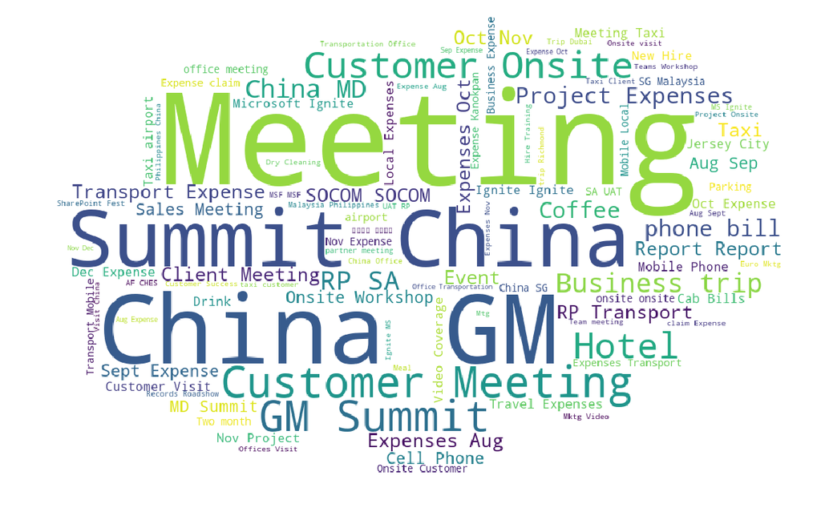

```python
time_ls = ['2018-12','2018-11','2018-10','2018-9']
endof2018_df = df[df['Sent for Payment Date'].apply(lambda x: x in time_ls)][df['Payment Type'] == 'Out-of-Pocket']
endof2018_df['Expense Type'] = endof2018_df['Expense Type'].map(my_func)

endof2018_df['Report Name'] = endof2018_df['Report Name'].astype(str)
endof2018_df['Purpose'] = endof2018_df['Purpose'].astype(str)

from wordcloud import WordCloud

text = "  ".join(endof2018_df['Purpose'].apply(filter_function).dropna()) + \
"  ".join(endof2018_df['Report Name'].apply(filter_function).dropna())

plt.subplots(figsize=(20,20))
wordcloud = WordCloud(background_color='white',
#                       colormap='ocean',
                      mask=mask,
                      max_words=100).generate(text)
plt.imshow(wordcloud)
plt.axis('off')

plt.show()
```

### Employee Spending by Categories in the End of 2018

```python
ls_exp_types = (endof2018_df
           .groupby(['Expense Type'])['Expense Amount (rpt)']
           .sum()
         .sort_values(ascending=False)
         .index[0:5])
tem_df = endof2018_df.copy()
tem_df['Expense Type'] = tem_df['Expense Type'].apply(lambda x: x if x in ls_exp_types else 'other misc types')

tem_df1 = (tem_df
           .groupby(['Employee','Expense Type'])['Expense Amount (rpt)']
           .sum()
           .unstack())

tem_df1['Total'] = tem_df1.sum(axis=1)
tem_df1 = tem_df1.sort_values('Total',ascending=False).iloc[0:10,:]

for col in tem_df1.columns:
    tem_df1[col] = tem_df1[col].apply(lambda x: round(x,2))
```

```python
traces = []

for col in tem_df1.columns:
    if col != 'Total':


        traces.append({'type' : 'bar',
                       'name' : col,
                       'x' : tem_df1.index,
                       'y' : tem_df1[col],
                       'opacity' : 0.7})

layout = {'title' : "Top 10 Employee Spending, Sep 2018 to Dec 2018",
         'xaxis' : {'title' : 'Employee','tickformat':'%b %y'},
         'yaxis' : {'title' : 'USD Amount','tickformat':'$,0'},
         'barmode' : 'stack'}

fig = {'data' : traces,
      'layout' : layout}
pyo.iplot(fig)
```

[interactive chart not shown]

## TODO:

1. We can add budget to the analysis to get a clearer image of our spending if it's available
2. Detailed EDA for each subsidiary
   - We just proved that the overall trend is predictable. The remaining job is to know the possibility to predict reimbursement for individual subsidiary, especially for those small subs.
   - For the large spending categories like Travel, Transportation and Meal, we can certainly drill down deeper and see what's really going on here.
3. Actionable Plots for users to check data online
4. Time series Modeling and Prediction

**Modification needed**

1. All figure in accounting format (thousand separator, 2 decimal places)
2. Use Year and Month, don't use Date
3. Keep One chart only (or less charts) for each overall estimating analysis